# Autocorrelation in R

Bidyut Kr. Ghosh

13 August 2017

```r
knitr::opts_chunk$set(echo = FALSE, comment = NA)
```

# Data Description and Model Estimation

We will consider the Blaisdell Company example from page 489 of Applied Linear Regression Models (4th ed) by Kutner, Nachtsheim, and Neter.
We will try to explain the company sales, ‘comsales’ ($ millions) with the help of single predictor variable, viz. ‘indsales’ by fitting a simple linear regression model.
The data is given in the text format (blaisdell.txt).
Mathematically we write the model as follows:
$${comsales}_t = \beta_0 +\beta_1 ({indsales}_t) +u_t$$
- Importing the data into R

- To fit the initial model to explain company sales with industry sales

```
Call:
lm(formula = comsales ~ indsales)

Residuals:
      Min        1Q    Median        3Q       Max
-0.149142 -0.054399 -0.000454  0.046425  0.163754

Coefficients:
             Estimate Std. Error t value Pr(>|t|)
(Intercept) -1.454750   0.214146  -6.793 2.31e-06 ***
indsales     0.176283   0.001445 122.017  < 2e-16 ***
---
Signif. codes:  0 '***' 0.001 '**' 0.01 '*' 0.05 '.' 0.1 ' ' 1

Residual standard error: 0.08606 on 18 degrees of freedom
Multiple R-squared:  0.9988,    Adjusted R-squared:  0.9987
F-statistic: 1.489e+04 on 1 and 18 DF,  p-value: < 2.2e-16
```

# Residual Diagnostic

- To save the residuals(uhat1) of the model
- To plot the residuals against time

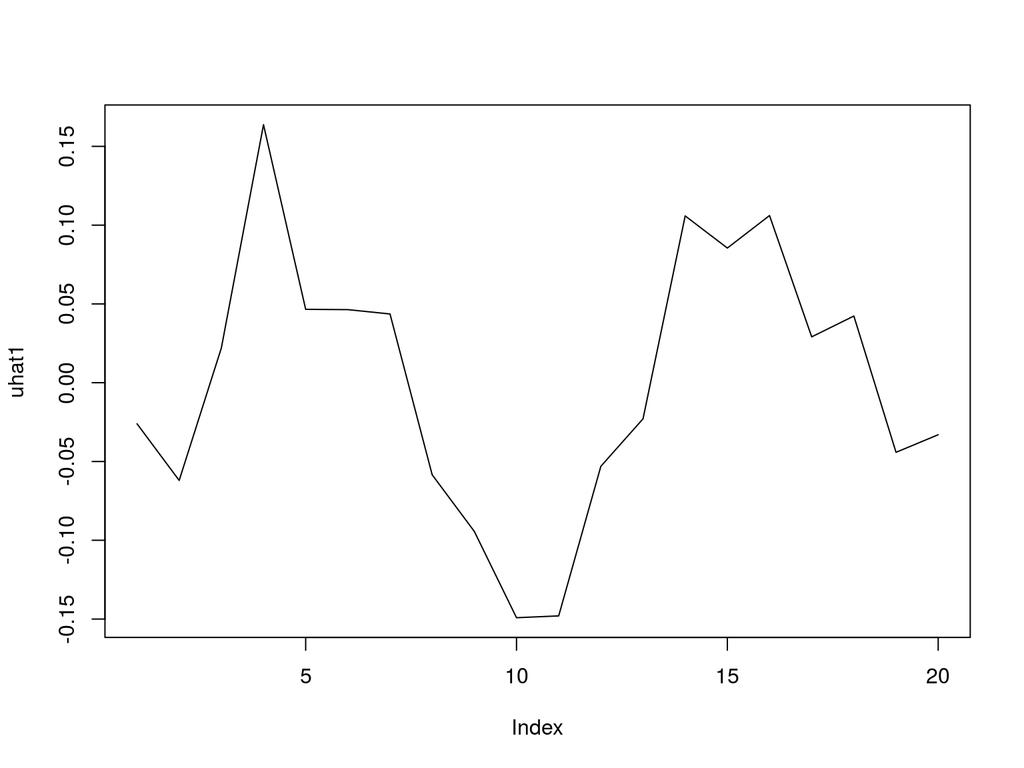

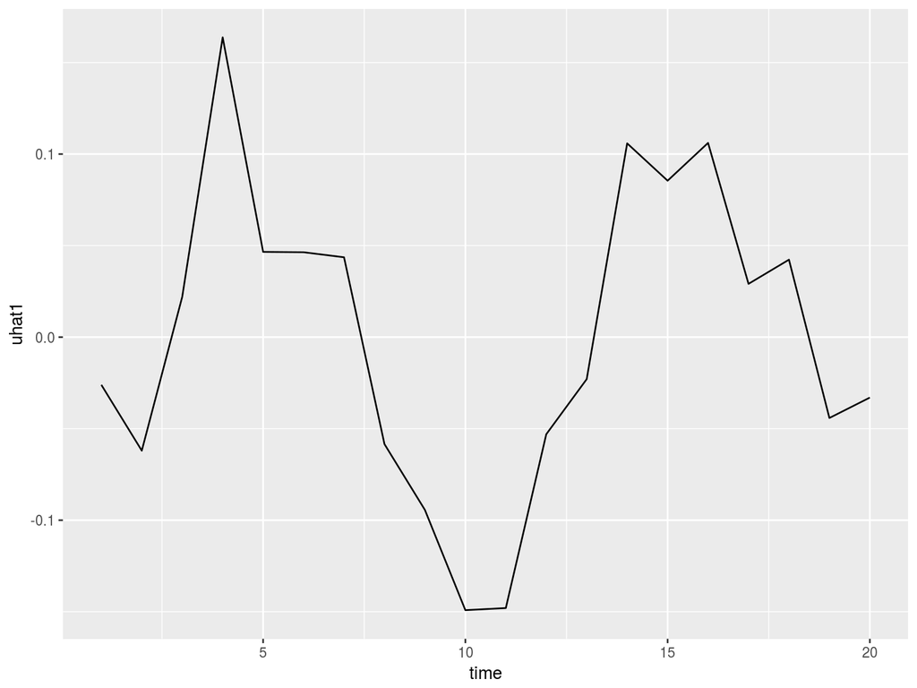

# Durbin-Watson test

```
 lag Autocorrelation D-W Statistic p-value
   1       0.6260046     0.7347256       0
 Alternative hypothesis: rho != 0
```

# Remedial Measures: Cochrane-Orcutt Procedure

```
Call:
lm(formula = comsales ~ indsales)

             Estimate Std. Error t value  Pr(>|t|)
(Intercept) 1.7389010  1.4326631   1.214    0.2414
indsales    0.1605234  0.0068253  23.519 2.085e-14 ***
---
Signif. codes:  0 '***' 0.001 '**' 0.01 '*' 0.05 '.' 0.1 ' ' 1

Residual standard error: 0.0649 on 17 degrees of freedom
Multiple R-squared:  0.9702 ,  Adjusted R-squared:  0.9684
F-statistic: 553.1 on 1 and 17 DF,  p-value: < 2.085e-14

Durbin-Watson statistic
(original):    0.73473 , p-value: 1.748e-04
(transformed): 1.72442 , p-value: 2.801e-01
```

# Remedial Measures: first-difference transformation model with no intercept term

```
Call:
lm(formula = diff(comsales, 1) ~ 0 + diff(indsales, 1))

Residuals:
     Min       1Q   Median       3Q      Max
-0.08958 -0.03231  0.02412  0.05344  0.15139

Coefficients:
                  Estimate Std. Error t value Pr(>|t|)
diff(indsales, 1) 0.168488   0.005096   33.06   <2e-16 ***
---
Signif. codes:  0 '***' 0.001 '**' 0.01 '*' 0.05 '.' 0.1 ' ' 1

Residual standard error: 0.06939 on 18 degrees of freedom
Multiple R-squared:  0.9838,    Adjusted R-squared:  0.9829
F-statistic:  1093 on 1 and 18 DF,  p-value: < 2.2e-16
```

-Durbin-Watson test on the first-difference model

```
 lag Autocorrelation D-W Statistic p-value
   1       0.1223879      1.738895    0.67
 Alternative hypothesis: rho != 0
```

# Advanced Autocorrelation Problem using the dataset “us_consumption.xls”

- Importing the dataset using “readxl” package

# Now we run the model to explain logarithm of consumption using logarithms of X variables in R and the results are shown below:

```
Call:
lm(formula = lnconsump ~ lndpi + lnwealth + interest)

Residuals:
      Min        1Q    Median        3Q       Max
-0.018441 -0.010001  0.000337  0.007038  0.032579

Coefficients:
              Estimate Std. Error t value Pr(>|t|)
(Intercept) -0.4677120  0.0427780 -10.933 7.33e-15 ***
lndpi        0.8048728  0.0174978  45.998  < 2e-16 ***
lnwealth     0.2012702  0.0175926  11.441 1.43e-15 ***
interest    -0.0026891  0.0007619  -3.529 0.000905 ***
---
Signif. codes:  0 '***' 0.001 '**' 0.01 '*' 0.05 '.' 0.1 ' ' 1

Residual standard error: 0.01193 on 50 degrees of freedom
Multiple R-squared:  0.9996,    Adjusted R-squared:  0.9995
F-statistic: 3.783e+04 on 3 and 50 DF,  p-value: < 2.2e-16
```

# To save the residuals of the model fit

# To plot the residuals of the model againt time

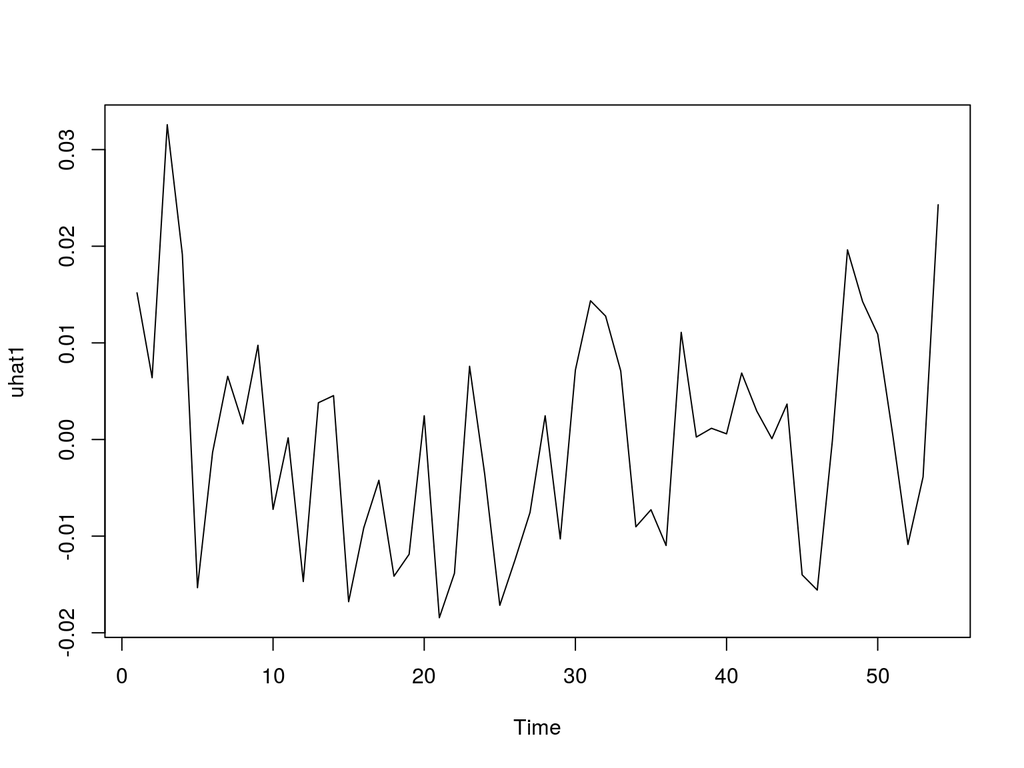

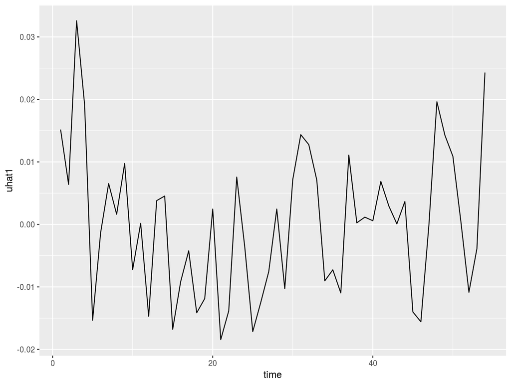

# To create the one-period lag of the saved residuals

# To plot the Current vs Lagged Residuals using basic graphics

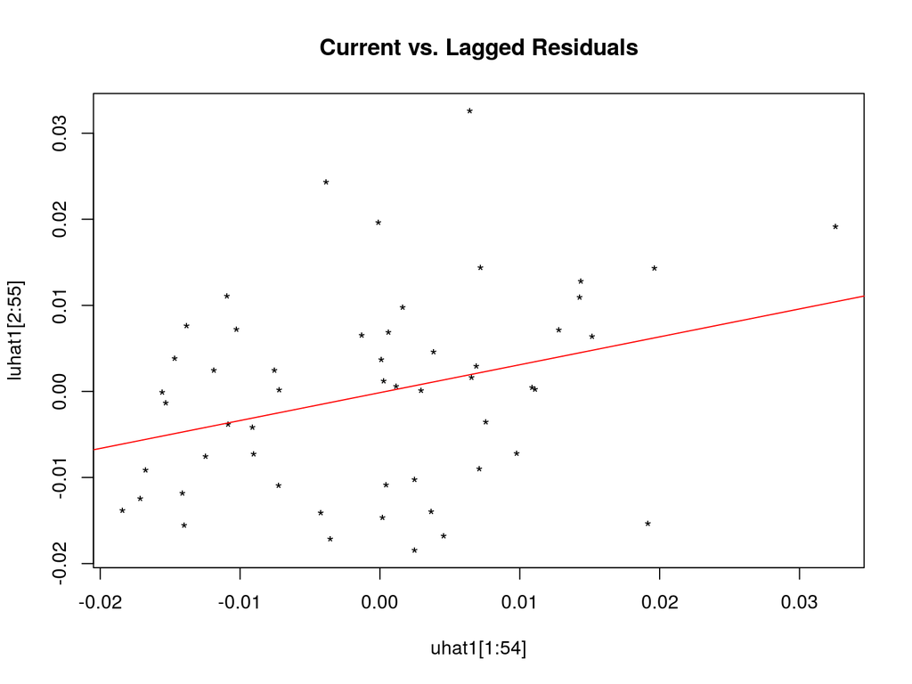

# To plot the Current vs Lagged Residuals using advanced graphics

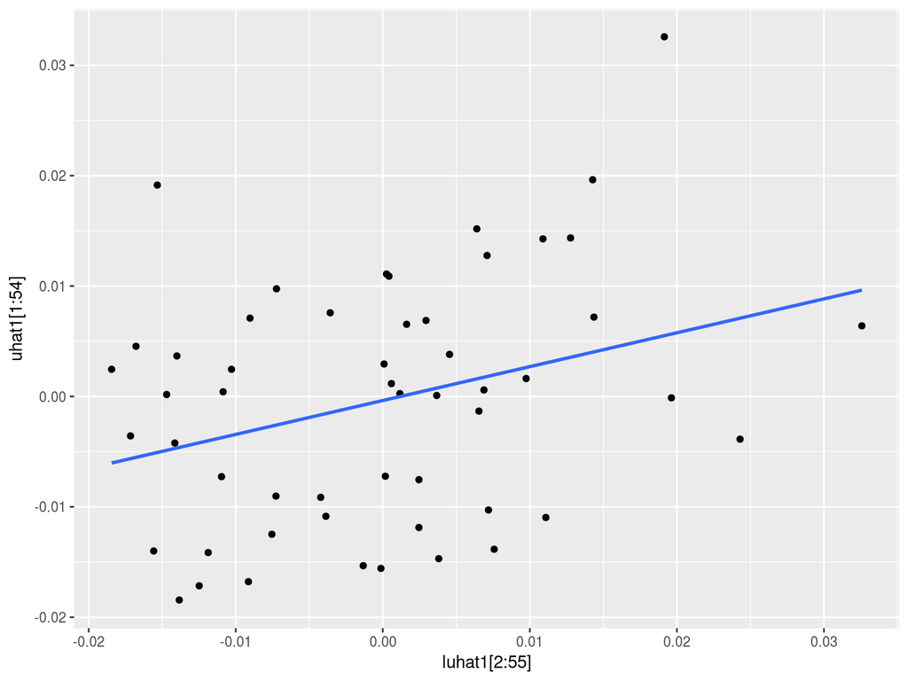

# To conduct the Durbin-Watson test

```
 lag Autocorrelation D-W Statistic p-value
   1       0.2977555      1.289232   0.002
 Alternative hypothesis: rho != 0
```

# To perform the Breusch–Godfrey (BG) test of autocorrelation.

```
    Breusch-Godfrey test for serial correlation of order up to 1

data:  fit4
LM test = 5.312, df = 1, p-value = 0.02118
```

# Remedial Measures for Autocorrelation: Using the first difference method

```
Call:
lm(formula = diff(lnconsump, 1) ~ 0 + diff(lndpi, 1) + diff(lnwealth,
    1) + diff(interest, 1))

Residuals:
      Min        1Q    Median        3Q       Max
-0.027810 -0.007000  0.002783  0.009686  0.023537

Coefficients:
                   Estimate Std. Error t value Pr(>|t|)
diff(lndpi, 1)    0.8489940  0.0515376  16.473  < 2e-16 ***
diff(lnwealth, 1) 0.1063550  0.0368543   2.886  0.00575 **
diff(interest, 1) 0.0006530  0.0008261   0.790  0.43297
---
Signif. codes:  0 '***' 0.001 '**' 0.01 '*' 0.05 '.' 0.1 ' ' 1

Residual standard error: 0.01113 on 50 degrees of freedom
Multiple R-squared:  0.9237,    Adjusted R-squared:  0.9191
F-statistic: 201.6 on 3 and 50 DF,  p-value: < 2.2e-16
```

# Breusch–Godfrey (BG) test of autocorrelation for the first difference model

```
    Breusch-Godfrey test for serial correlation of order up to 1

data:  fit5
LM test = 0.86275, df = 1, p-value = 0.353
```

# Remedial Measures for Autocorrelation: Generalized Transformation

- To save the residuals of the initial model (fit4)
- To generate the one-period lag of the residuals.

# For estimating the rho

```
Call:
lm(formula = uhat4 ~ 0 + luhat4)

Residuals:
       Min         1Q     Median         3Q        Max
-0.0215503 -0.0078554  0.0002091  0.0066878  0.0305027

Coefficients:
       Estimate Std. Error t value Pr(>|t|)
luhat4   0.3247     0.1351   2.402   0.0199 *
---
Signif. codes:  0 '***' 0.001 '**' 0.01 '*' 0.05 '.' 0.1 ' ' 1

Residual standard error: 0.01092 on 52 degrees of freedom
  (1 observation deleted due to missingness)
Multiple R-squared:  0.09991,   Adjusted R-squared:  0.0826
F-statistic: 5.772 on 1 and 52 DF,  p-value: 0.01989
```

# Thus, rho hat is found to be 0.3247. Further, we can recheck it approximately using D-W statistic

```
 lag Autocorrelation D-W Statistic p-value
   1       0.2977555      1.289232   0.002
 Alternative hypothesis: rho != 0
```

# Complete transformation

# To estimate the transformed model

```
Call:
lm(formula = Cstar ~ Ystar + Wstar + rstar)

Residuals:
      Min        1Q    Median        3Q       Max
-0.017901 -0.006608 -0.001012  0.006385  0.025941

Coefficients:
              Estimate Std. Error t value Pr(>|t|)
(Intercept) -2.797e-01  3.373e-02  -8.294 6.81e-11 ***
Ystar        8.187e-01  2.110e-02  38.806  < 2e-16 ***
Wstar        1.836e-01  2.099e-02   8.749 1.40e-11 ***
rstar       -1.782e-05  9.691e-04  -0.018    0.985
---
Signif. codes:  0 '***' 0.001 '**' 0.01 '*' 0.05 '.' 0.1 ' ' 1

Residual standard error: 0.01042 on 49 degrees of freedom
  (1 observation deleted due to missingness)
Multiple R-squared:  0.9992,    Adjusted R-squared:  0.9992
F-statistic: 2.133e+04 on 3 and 49 DF,  p-value: < 2.2e-16
```